```python
project_name = "german-credit-risk"
```

# German Credit Data Analysis

Loans form an integral part of banking operations. However, not all the loans are promptly returned and hence it is important for a bank to closely monitter its loan applications. This project is an analysis of the German credit dataset from the UCI Machine Learning repository. The dataset contains details of 1000 loan applicants with 21 attributes along with the classification as good or bad credit.

In this project, the relationship between the credit risk and various attribues will be explored through basic statistical techniques, and presented through visualizations.

**Contents**

1. Import data
2. Data preparation, cleaning
3. Exploratory data analysis
4. Feature engineering
5. Models
6. Summary
7. References, future work

## 1. Import data

Let's begin by downloading the data from the [UCI Machine Learning repository](http://archive.ics.uci.edu/ml/about.html).

```python
from urllib.request import urlretrieve
urlretrieve('http://archive.ics.uci.edu/ml/machine-learning-databases/statlog/german/german.data', 'german.data')
```

```
('german.data', <http.client.HTTPMessage at 0x7effdfbb5550>)
```

The dataset has been downloaded and extracted.

## 2. Data Preparation and Cleaning

In this step, we do data preparation and cleaning, making the data suitable for subsequent analysis.

**2.1 Load data into dataframe**

The datafile is in `.data` format, delimited with space, and has no headers.

```python
import pandas as pd
german_df = pd.read_csv('http://archive.ics.uci.edu/ml/machine-learning-databases/statlog/german/german.data',
                        delimiter=' ',header=None)
```

Now, let's have an over-view of the dataset.

```python
german_df.info()
```

```
<class 'pandas.core.frame.DataFrame'>
RangeIndex: 1000 entries, 0 to 999
Data columns (total 21 columns):
 #   Column  Non-Null Count  Dtype
---  ------  --------------  -----
 0   0       1000 non-null   object
 1   1       1000 non-null   int64
 2   2       1000 non-null   object
 3   3       1000 non-null   object
 4   4       1000 non-null   int64
 5   5       1000 non-null   object
 6   6       1000 non-null   object
 7   7       1000 non-null   int64
 8   8       1000 non-null   object
 9   9       1000 non-null   object
 10  10      1000 non-null   int64
 11  11      1000 non-null   object
 12  12      1000 non-null   int64
 13  13      1000 non-null   object
 14  14      1000 non-null   object
 15  15      1000 non-null   int64
 16  16      1000 non-null   object
 17  17      1000 non-null   int64
 18  18      1000 non-null   object
 19  19      1000 non-null   object
 20  20      1000 non-null   int64
dtypes: int64(8), object(13)
memory usage: 164.2+ KB
```

The dataset contains 21 variables and 1000 observatios. 8 variables are of numeric type and 13 of object type. As the object type variables do not have any null values, we can conclude that they are of categorical type.

**2.2 Label the columns**

Next, let's label the variables for ease of use. The document) describing the dataset may be referred for this.

```python
urlretrieve('http://archive.ics.uci.edu/ml/machine-learning-databases/statlog/german/german.doc', 'german.doc')
f = open('german.doc')
german_doc= f.read()
print(german_doc)
```

```
Description of the German credit dataset.

1. Title: German Credit data

2. Source Information

Professor Dr. Hans Hofmann
Institut f"ur Statistik und "Okonometrie
Universit"at Hamburg
FB Wirtschaftswissenschaften
Von-Melle-Park 5
2000 Hamburg 13

3. Number of Instances:  1000

Two datasets are provided.  the original dataset, in the form provided
by Prof. Hofmann, contains categorical/symbolic attributes and
is in the file "german.data".

For algorithms that need numerical attributes, Strathclyde University
produced the file "german.data-numeric".  This file has been edited
and several indicator variables added to make it suitable for
algorithms which cannot cope with categorical variables.   Several
attributes that are ordered categorical (such as attribute 17) have
been coded as integer.    This was the form used by StatLog.


6. Number of Attributes german: 20 (7 numerical, 13 categorical)
   Number of Attributes german.numer: 24 (24 numerical)


7.  Attribute description for german

Attribute 1:  (qualitative)
	       Status of existing checking account
               A11 :      ... <    0 DM
	       A12 : 0 <= ... <  200 DM
	       A13 :      ... >= 200 DM /
		     salary assignments for at least 1 year
               A14 : no checking account
```

[output cut: 119 more lines]

```


      1        2
----------------------------
  1   0        1
-----------------------
  2   5        0

(1 = Good,  2 = Bad)

the rows represent the actual classification and the columns
the predicted classification.

It is worse to class a customer as good when they are bad (5),
than it is to class a customer as bad when they are good (1).
```

Based on the description, we name the columns.

```python
german_df.columns=['account_bal','duration','payment_status','purpose',
                   'credit_amount','savings_bond_value','employed_since',
                   'intallment_rate','sex_marital','guarantor','residence_since',
                   'most_valuable_asset','age','concurrent_credits','type_of_housing',
                   'number_of_existcr','job','number_of_dependents','telephon',
                   'foreign','target']
```

```python
german_df= german_df.replace(['A11','A12','A13','A14', 'A171','A172','A173','A174','A121','A122','A123','A124'],
                  ['neg_bal','positive_bal','positive_bal','no_acc','unskilled','unskilled','skilled','highly_skilled',
                   'none','car','life_insurance','real_estate'])
```

## 3. Exploratory Data Analysis and Visualization

```python
# import libraries for visualizations

import numpy as np
import seaborn as sns
import matplotlib
import matplotlib.pyplot as plt
%matplotlib inline

sns.set_style('darkgrid')
matplotlib.rcParams['font.size'] = 14
matplotlib.rcParams['figure.figsize'] = (9, 5)
matplotlib.rcParams['figure.facecolor'] = '#00000000'
```

**3.1 Examine missing values**

```python
# check for missing values
german_df.isna().any().any()
```

```
False
```

**3.1 Examine distribution of target column**

```python
german_df.target.unique()
```

```
array([1, 2])
```

The `target` column has two values:

- 1: representing a good loan
- 2: representing a bad (defaulted) loan.

The usual convention is to use '1' for bad loans and '0' for good loans. Let's replace the values to comply to the convention.

```python
from sklearn.preprocessing import LabelEncoder

le= LabelEncoder()
le.fit(german_df.target)
german_df.target=le.transform(german_df.target)
german_df.target.head(5)
```

```
0    0
1    1
2    0
3    0
4    1
Name: target, dtype: int64
```

An understanding of the percentage of good and bad loans would be useful for the further analysis. A pie chart would be best tool to help with this.

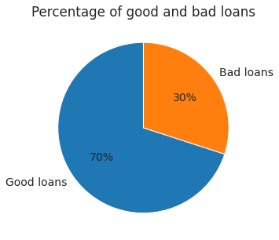

```python
good_bad_per=round(((german_df.target.value_counts()/german_df.target.count())*100))
good_bad_per
plt.pie(good_bad_per,labels=['Good loans', 'Bad loans'], autopct='%1.0f%%', startangle=90)
plt.title('Percentage of good and bad loans');
```

The pie chart shows that 30% of the loan applicants defaulted. From this information, we see that this is an imbalanced class problem. Hence, we will have to weigh the classes by their representation in the data to reflect this imbalance.

**4.2 Exploration of continues variables**

- Summary statistics
- Histograms
- Box-plots

**Observations**

```python
german_df[['credit_amount','duration','age']].describe()
```

|  | credit_amount | duration | age |
| --- | --- | --- | --- |
| count | 1000.000000 | 1000.000000 | 1000.000000 |
| mean | 3271.258000 | 20.903000 | 35.546000 |
| std | 2822.736876 | 12.058814 | 11.375469 |
| min | 250.000000 | 4.000000 | 19.000000 |
| 25% | 1365.500000 | 12.000000 | 27.000000 |
| 50% | 2319.500000 | 18.000000 | 33.000000 |
| 75% | 3972.250000 | 24.000000 | 42.000000 |
| max | 18424.000000 | 72.000000 | 75.000000 |

```python
german_df['credit_amount']=np.log(german_df['credit_amount'])
```

```python
german_df[['credit_amount','duration','age']].describe()
```

|  | credit_amount | duration | age |
| --- | --- | --- | --- |
| count | 1000.000000 | 1000.000000 | 1000.000000 |
| mean | 7.788691 | 20.903000 | 35.546000 |
| std | 0.776474 | 12.058814 | 11.375469 |
| min | 5.521461 | 4.000000 | 19.000000 |
| 25% | 7.219276 | 12.000000 | 27.000000 |
| 50% | 7.749107 | 18.000000 | 33.000000 |
| 75% | 8.287088 | 24.000000 | 42.000000 |
| max | 9.821409 | 72.000000 | 75.000000 |

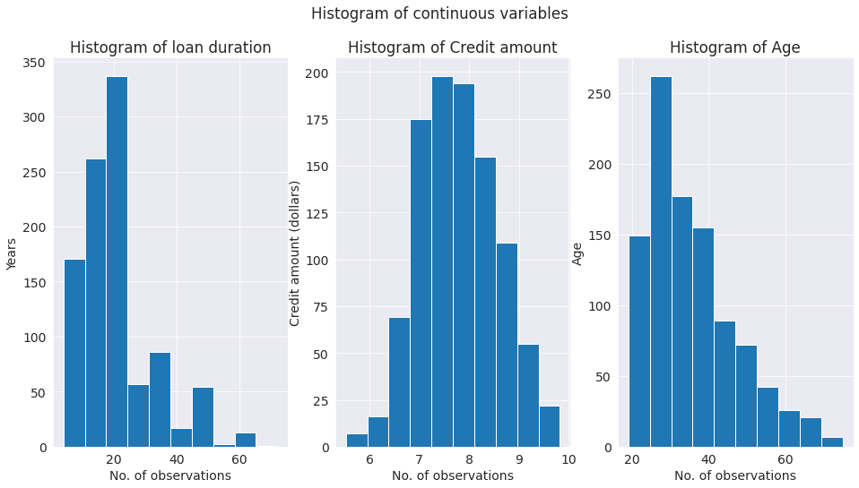

```python
# histograms of continues variables

fig, axes = plt.subplots(1,3, figsize=(16,8))
plt.suptitle('Histogram of continuous variables')
axes[0].hist(german_df['duration'])
axes[0].set_xlabel('No. of observations')
axes[0].set_ylabel('Years')
axes[0].set_title('Histogram of loan duration');

axes[1].hist(german_df['credit_amount'])
axes[1].set_xlabel('No. of observations')
axes[1].set_ylabel('Credit amount (dollars)')
axes[1].set_title('Histogram of Credit amount');

axes[2].hist(german_df['age'])
axes[2].set_xlabel('No. of observations')
axes[2].set_ylabel('Age')
axes[2].set_title('Histogram of Age');
```

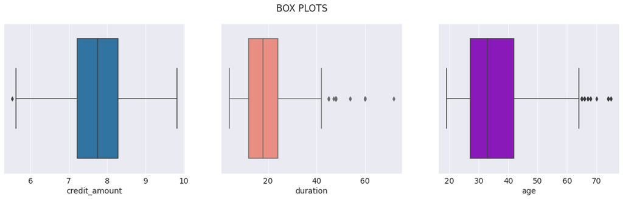

```python
# box-plots of continues variables

fig, ax = plt.subplots(1,3,figsize=(20,5))
plt.suptitle('BOX PLOTS')
sns.boxplot(german_df['credit_amount'], ax=ax[0]);
sns.boxplot(german_df['duration'], ax=ax[1], color='salmon');
sns.boxplot(german_df['age'], ax=ax[2], color='darkviolet');
```

**4.2 Relationship between the credit amount and repayment duration**

- scatter plot

**Observations**

The scatter plot shows that in general, larger loans have longer duration of repayment. Cases where large loans are given with short repayment period have turned out to be bad loans.

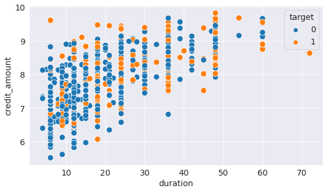

```python
sns.scatterplot(y=german_df.credit_amount,
                x=german_df.duration,
                hue=german_df.target,
                s=100,
                );
```

**4.3 Exploration of categorical variables**

**Relationship between credit risk and skills of loan applicant**

- Bar-graph

**Observations**

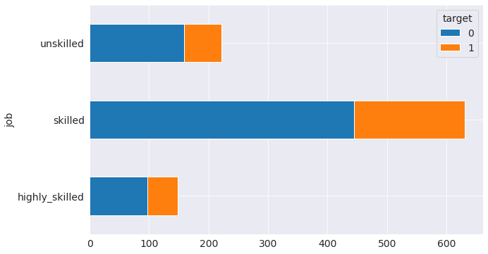

```python
german_df.groupby('job')['target'].value_counts().unstack(level=1).plot.barh(stacked=True, figsize=(10, 6))
```

**4.4 Relationship between credit amount and duration of the loan**

- Line graph

**Observation**

There is a linear relationship between the credit amount and duration. The larger the credit amount, the longer is the repayment duration.

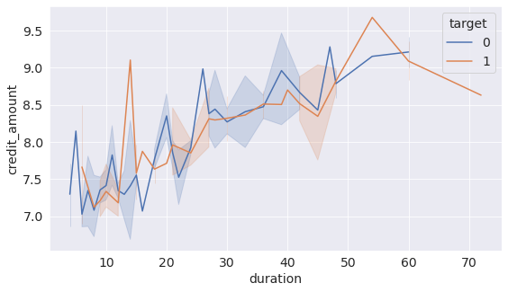

```python
sns.lineplot(data=german_df, x='duration', y='credit_amount', hue='target', palette='deep');
```

**4.5 Relationship between the most valuable asset of the candidate and the credit amount, credit risk**

- stacked bar chart
- scatter plot

The categorical coding used in the graphs is :

- A121 : real estate
- A122 : if not A121 : building society savings agreement/life insurance
- A123 : if not A121/A122 : car or other, not in attribute 6
- A124 : unknown / no property

**Observations**

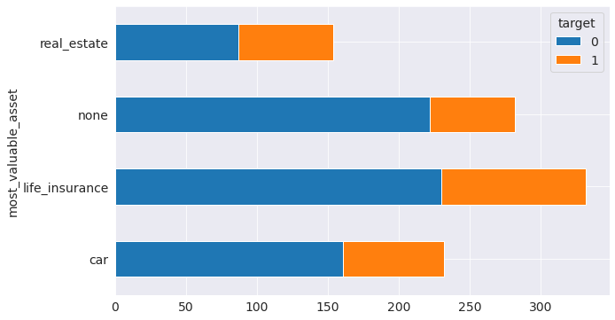

```python
german_df.groupby('most_valuable_asset')['target'].value_counts().unstack(level=1).plot.barh(stacked=True, figsize=(10, 6))
```

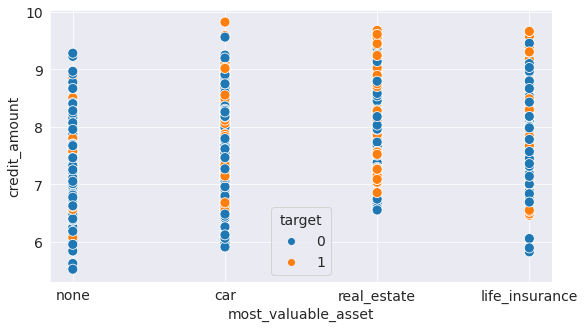

```python
sns.scatterplot(y=german_df.credit_amount,
                x=german_df.most_valuable_asset,
                hue=german_df.target,
                s=100,
                );
```

## 4. Encode categorical variables

Most machine learning models cannot deal with categorical variables. So we need to encode the 13 categorical variables that we have in the german dataset.

```python
# Number of unique classes in each object column
german_df.select_dtypes('object').apply(pd.Series.nunique, axis = 0)
```

```
account_bal             3
payment_status          5
purpose                10
savings_bond_value      5
employed_since          5
sex_marital             4
guarantor               3
most_valuable_asset     4
concurrent_credits      3
type_of_housing         3
job                     3
telephon                2
foreign                 2
dtype: int64
```

We have categorical variables with 2 to 10 categories. We go for Label encoding for variables with only two categories where as for variables with more than two categories, we go for one-hot encoding. In label encoding, we assign each unique category in a categorical variable with an integer. No new columns are created. In one-hot encoding, we create a new column for each unique category in a categorical variable. The only downside to one-hot encoding is that the number of features (dimensions of the data) can explode with categorical variables with many categories. To deal with this, we can perform one-hot encoding followed by PCA or other dimensionality reduction methods to reduce the number of dimensions (while still trying to preserve information).

For label encoding, we use the Scikit-Learn LabelEncoder and for one-hot encoding, the pandas get_dummies(df) function.

```python
# sklearn preprocessing for dealing with categorical variables
from sklearn.preprocessing import LabelEncoder

# Create a label encoder object
le = LabelEncoder()
le_count = 0

# Iterate through the columns
for col in german_df:
    if german_df[col].dtype == 'object':
        # If 2 or fewer unique categories
        if len(list(german_df[col].unique())) <= 2:
            # Train on the training data
            le.fit(german_df[col])
            # Transform both training and testing data
            german_df[col] = le.transform(german_df[col])

            # Keep track of how many columns were label encoded
            le_count += 1

print('%d columns were label encoded.' % le_count)
```

```
2 columns were label encoded.
```

```python
# one-hot encoding of categorical variables
german_df = pd.get_dummies(german_df)

print('Encoded Features shape: ', german_df.shape)
```

```
Encoded Features shape:  (1000, 58)
```

Now that we have encoded the variables, let's continue with the EDA.

**4.1 Correlation between the variables**

Let's look at correlations between the features and the target using Pearson correlation coefficient. In this case, a postive correlation represnets correlation with credit default while a negative correlation represnets correlation with credit repayment.

**Observations:**

Positive correlation:

Negative correlation:

```python
# Find correlations with the target and sort
correlations = german_df.corr()['target'].sort_values()

# Display correlations
print('Most Positive Correlations:\n', correlations.tail(15))
print('\nMost Negative Correlations:\n', correlations.head(15))
```

```
Most Positive Correlations:
 sex_marital_A92                    0.075493
type_of_housing_A153               0.081556
account_bal_positive_bal           0.089895
type_of_housing_A151               0.092785
concurrent_credits_A141            0.096510
purpose_A40                        0.096900
employed_since_A72                 0.106397
credit_amount                      0.109570
most_valuable_asset_real_estate    0.125750
payment_status_A31                 0.134448
payment_status_A30                 0.144767
savings_bond_value_A61             0.161007
duration                           0.214927
account_bal_neg_bal                0.258333
target                             1.000000
Name: target, dtype: float64

Most Negative Correlations:
 account_bal_no_acc         -0.322436
payment_status_A34         -0.181713
type_of_housing_A152       -0.134589
savings_bond_value_A65     -0.129238
most_valuable_asset_none   -0.119300
concurrent_credits_A143    -0.113285
purpose_A43                -0.106922
purpose_A41                -0.099791
age                        -0.091127
savings_bond_value_A64     -0.085749
foreign                    -0.082079
sex_marital_A93            -0.080677
employed_since_A74         -0.075980
savings_bond_value_A63     -0.070954
employed_since_A75         -0.059733
Name: target, dtype: float64
```

Let's look at the heatmap of significant correlations.

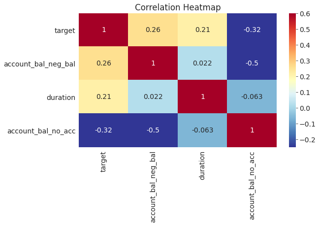

```python
# Extract the significantly correlated variables
corr_data = german_df[['target', 'account_bal_neg_bal','duration','account_bal_no_acc']]
corr_data_corrs = corr_data.corr()


# Heatmap of correlations
sns.heatmap(corr_data_corrs, cmap = plt.cm.RdYlBu_r, vmin = -0.25, annot = True, vmax = 0.6)
plt.title('Correlation Heatmap');
```

## 5. Feature engineering

Feature engineering refers to creating most useful features out of the data. This represents one of the patterns in machine learning: feature engineering has a greater return on investment than model building and hyperparameter tuning. [[Source]](https://www.featurelabs.com/blog/secret-to-data-science-success/)

Feature engineering refers to a geneal process and can involve both **feature construction**: adding new features from the existing data, and **feature selection**: choosing only the most important features or other methods of dimensionality reduction. There are many techniques we can use to both create features and select features.

For this problem, we will try to construct polynomial features.

### Polynomial Features

Here, we find interactions between the significant features. The correlation between the interaction features are target are checked.If the interaction features are found to have greater correlation with the target compared to the original features, they are included in the machine learning model as they can help the model learn better.

```python
# Make a new dataframe for polynomial features
poly_features = german_df[['duration','account_bal_neg_bal','account_bal_no_acc']]
poly_target=german_df['target']

from sklearn.preprocessing import PolynomialFeatures

# Create the polynomial object with specified degree
poly_transformer = PolynomialFeatures(degree = 2)
# Train the polynomial features
poly_transformer.fit(poly_features)

# Transform the features
poly_features = poly_transformer.transform(poly_features)
print('Polynomial Features shape: ', poly_features.shape)
```

```
Polynomial Features shape:  (1000, 10)
```

This creates a considerable number of new features. To get the names we have to use the polynomial features `get_feature_names` method.

```python
poly_transformer.get_feature_names(input_features = ['duration','account_bal_neg_bal','account_bal_no_acc'])
```

```
['1',
 'duration',
 'account_bal_neg_bal',
 'account_bal_no_acc',
 'duration^2',
 'duration account_bal_neg_bal',
 'duration account_bal_no_acc',
 'account_bal_neg_bal^2',
 'account_bal_neg_bal account_bal_no_acc',
 'account_bal_no_acc^2']
```

Now, we can see whether any of these new features are correlated with the target.

```python
# Create a dataframe for polynomial features
poly_features = pd.DataFrame(
    poly_features, columns = poly_transformer.get_feature_names(
        ['duration','account_bal_neg_bal','account_bal_no_acc']))

# Add in the target
poly_features['target'] = poly_target

# Find the correlations with the target
poly_corrs = poly_features.corr()['target'].sort_values()

# Display the correlations
poly_corrs
```

```
account_bal_no_acc                       -0.322436
account_bal_no_acc^2                     -0.322436
duration account_bal_no_acc              -0.232697
duration^2                                0.200996
duration                                  0.214927
account_bal_neg_bal                       0.258333
account_bal_neg_bal^2                     0.258333
duration account_bal_neg_bal              0.303343
target                                    1.000000
1                                              NaN
account_bal_neg_bal account_bal_no_acc         NaN
Name: target, dtype: float64
```

```python
list(poly_features)
```

```
['1',
 'duration',
 'account_bal_neg_bal',
 'account_bal_no_acc',
 'duration^2',
 'duration account_bal_neg_bal',
 'duration account_bal_no_acc',
 'account_bal_neg_bal^2',
 'account_bal_neg_bal account_bal_no_acc',
 'account_bal_no_acc^2',
 'target']
```

```python
# deleting duplicate columns in poly_features

for i in list(poly_features.columns):
  for j in list(german_df.columns):
    if (i==j):
      poly_features.drop(labels=i, axis=1, inplace=True)

poly_features.drop(labels='1', axis=1, inplace=True)
list(poly_features)
```

```
['duration^2',
 'duration account_bal_neg_bal',
 'duration account_bal_no_acc',
 'account_bal_neg_bal^2',
 'account_bal_neg_bal account_bal_no_acc',
 'account_bal_no_acc^2']
```

```python
# Print shape of original german_df
print('Original features shape: ', german_df.shape)

# Merge polnomial features into the dataframe
german_df_poly = german_df.merge(poly_features, left_index=True, right_index=True, how = 'left')

# Print out the new shapes
print('Merged polynomial features shape: ', german_df_poly.shape)
```

```
Original features shape:  (1000, 58)
Merged polynomial features shape:  (1000, 64)
```

```python
german_df_poly.isna().any().any()
```

```
False
```

```python
list(german_df_poly)
```

```
['duration',
 'credit_amount',
 'intallment_rate',
 'residence_since',
 'age',
 'number_of_existcr',
 'number_of_dependents',
 'telephon',
 'foreign',
 'target',
 'account_bal_neg_bal',
 'account_bal_no_acc',
 'account_bal_positive_bal',
 'payment_status_A30',
 'payment_status_A31',
 'payment_status_A32',
 'payment_status_A33',
 'payment_status_A34',
 'purpose_A40',
 'purpose_A41',
 'purpose_A410',
 'purpose_A42',
 'purpose_A43',
 'purpose_A44',
 'purpose_A45',
 'purpose_A46',
 'purpose_A48',
 'purpose_A49',
 'savings_bond_value_A61',
 'savings_bond_value_A62',
 'savings_bond_value_A63',
 'savings_bond_value_A64',
 'savings_bond_value_A65',
 'employed_since_A71',
 'employed_since_A72',
 'employed_since_A73',
 'employed_since_A74',
 'employed_since_A75',
 'sex_marital_A91',
 'sex_marital_A92',
```

[output cut: 9 more lines]

```
 'concurrent_credits_A141',
 'concurrent_credits_A142',
 'concurrent_credits_A143',
 'type_of_housing_A151',
 'type_of_housing_A152',
 'type_of_housing_A153',
 'job_highly_skilled',
 'job_skilled',
 'job_unskilled',
 'duration^2',
 'duration account_bal_neg_bal',
 'duration account_bal_no_acc',
 'account_bal_neg_bal^2',
 'account_bal_neg_bal account_bal_no_acc',
 'account_bal_no_acc^2']
```

## 6. Data split to train and test datasets

As the german dataset is an imabalnced dataset with more number repayers compared to defaulters, we used stratified random `test_train_split` to split the dataset into random test and train datasets so that relative class frequencies are preserved.

```python
from sklearn.model_selection import train_test_split
```

```python
x, y = german_df.drop('target', axis=1), german_df['target']
x.shape, y.shape
```

```
((1000, 57), (1000,))
```

```python
x_train, x_test, y_train, y_test= train_test_split(x,y, test_size=.2, random_state=42, stratify=y)
```

```python
x_train.shape, x_test.shape
```

```
((800, 57), (200, 57))
```

```python
x_train
```

|  | duration | credit_amount | intallment_rate | residence_since | age | number_of_existcr | number_of_dependents | telephon | foreign | account_bal_neg_bal | account_bal_no_acc | account_bal_positive_bal | payment_status_A30 | payment_status_A31 | payment_status_A32 | payment_status_A33 | payment_status_A34 | purpose_A40 | purpose_A41 | purpose_A410 | purpose_A42 | purpose_A43 | purpose_A44 | purpose_A45 | purpose_A46 | purpose_A48 | purpose_A49 | savings_bond_value_A61 | savings_bond_value_A62 | … |
| --- | --- | --- | --- | --- | --- | --- | --- | --- | --- | --- | --- | --- | --- | --- | --- | --- | --- | --- | --- | --- | --- | --- | --- | --- | --- | --- | --- | --- | --- | --- |
| 828 | 36 | 9.028219 | 3 | 4 | 47 | 1 | 1 | 0 | 0 | 1 | 0 | 0 | 0 | 0 | 1 | 0 | 0 | 0 | 1 | 0 | 0 | 0 | 0 | 0 | 0 | 0 | 0 | 0 | 0 | … |
| 997 | 12 | 6.689599 | 4 | 4 | 38 | 1 | 1 | 0 | 0 | 0 | 1 | 0 | 0 | 0 | 1 | 0 | 0 | 0 | 0 | 0 | 0 | 1 | 0 | 0 | 0 | 0 | 0 | 1 | 0 | … |
| 148 | 36 | 8.588769 | 3 | 2 | 28 | 2 | 1 | 0 | 0 | 1 | 0 | 0 | 0 | 0 | 0 | 0 | 1 | 0 | 0 | 0 | 1 | 0 | 0 | 0 | 0 | 0 | 0 | 1 | 0 | … |
| 735 | 36 | 8.291547 | 3 | 2 | 29 | 1 | 1 | 0 | 0 | 0 | 0 | 1 | 0 | 1 | 0 | 0 | 0 | 0 | 0 | 0 | 0 | 0 | 1 | 0 | 0 | 0 | 0 | 0 | 0 | … |
| 130 | 48 | 9.046291 | 1 | 2 | 24 | 1 | 1 | 0 | 0 | 0 | 0 | 1 | 0 | 0 | 1 | 0 | 0 | 1 | 0 | 0 | 0 | 0 | 0 | 0 | 0 | 0 | 0 | 0 | 0 | … |
| ... | ... | ... | ... | ... | ... | ... | ... | ... | ... | ... | ... | ... | ... | ... | ... | ... | ... | ... | ... | ... | ... | ... | ... | ... | ... | ... | ... | ... | ... | … |
| 492 | 6 | 7.120444 | 1 | 1 | 27 | 2 | 1 | 0 | 0 | 0 | 1 | 0 | 0 | 0 | 0 | 0 | 1 | 0 | 0 | 0 | 0 | 1 | 0 | 0 | 0 | 0 | 0 | 0 | 1 | … |
| 545 | 24 | 7.195187 | 4 | 2 | 43 | 2 | 2 | 0 | 0 | 1 | 0 | 0 | 0 | 0 | 0 | 1 | 0 | 1 | 0 | 0 | 0 | 0 | 0 | 0 | 0 | 0 | 0 | 1 | 0 | … |
| 298 | 18 | 7.830028 | 3 | 4 | 43 | 1 | 1 | 1 | 0 | 0 | 1 | 0 | 0 | 0 | 1 | 0 | 0 | 0 | 0 | 0 | 1 | 0 | 0 | 0 | 0 | 0 | 0 | 1 | 0 | … |
| 417 | 18 | 9.044404 | 1 | 2 | 23 | 2 | 1 | 1 | 0 | 1 | 0 | 0 | 0 | 0 | 0 | 1 | 0 | 0 | 0 | 0 | 0 | 0 | 0 | 0 | 1 | 0 | 0 | 0 | 0 | … |
| 749 | 15 | 8.015988 | 2 | 2 | 33 | 1 | 1 | 0 | 0 | 0 | 1 | 0 | 0 | 0 | 1 | 0 | 0 | 0 | 1 | 0 | 0 | 0 | 0 | 0 | 0 | 0 | 0 | 1 | 0 | … |

800 rows × 57 columns

```python
y_train
```

```
828    1
997    0
148    0
735    0
130    0
      ..
492    0
545    1
298    0
417    0
749    0
Name: target, Length: 800, dtype: int64
```

```python
# train and test split on german_df_poly
X, Y = german_df_poly.drop('target', axis=1), german_df_poly['target']
print(X.shape, Y.shape)

X_train, X_test, Y_train, Y_test= train_test_split(X,Y, test_size=.2, random_state=42, stratify=Y)
```

```
(1000, 63) (1000,)
```

## 7. Models

**Evaluation criteria**

Let's have a look at the different options available.

[output not shown]

- Accuracy: The german dataset is an imbalanced dataset. Accuracy would give a high score by predicting the majority class but would fail to predict the minority class, which is the defaulters. Hence, this is not a suitable metric for this dataset.
- Precision: Precision is a good metric when the costs of false positive is high. Example, email spam detection.
- Recall: This metric is suitable when the costs of false negative is high. Example, predicting a defulter as not defaulter. This costs huge loss for the bank. Hence, this is a suitable metric for our case.
- F1: measure of both precision and recall.
- AUC ROC: It is the plot of TPR vs FPR. All other criteria discussed here assumes 0.5 as the decision threshold for the classification. However, it maynot be always true. The AUC helps us evaluate the performance of the model for all classification thresholds. The higher the value of the AUC metric, the better the model.
- True positive rate (TPR) = TP/ Total actual positive
- False positive rate (FPR) = FP/ Total actual negative

We will use Recall and AUC ROC as evaluation metric.

**Baseline**

```python
y.value_counts(normalize=True)
```

```
0    0.7
1    0.3
Name: target, dtype: float64
```

**Models without tuning**

```python
# import packages, functions, and classes
from sklearn.ensemble import RandomForestClassifier
from sklearn.linear_model import LogisticRegression
from sklearn.tree import DecisionTreeClassifier
from sklearn.neighbors import KNeighborsClassifier
from sklearn.ensemble import RandomForestClassifier
from sklearn.discriminant_analysis import LinearDiscriminantAnalysis
from sklearn.naive_bayes import GaussianNB
from sklearn.svm import SVC
from xgboost import XGBClassifier

from sklearn.metrics import roc_auc_score, recall_score, classification_report
from sklearn.model_selection import StratifiedKFold, cross_val_score, cross_validate
```

```python
# prepare models
models = []
models.append(('DT', DecisionTreeClassifier(random_state=42)))
models.append(('LR', LogisticRegression(random_state=42)))
models.append(('RF', RandomForestClassifier(random_state=42)))
models.append(('NB', GaussianNB()))
models.append(('XGB', XGBClassifier(random_state=42)))
models.append(('KNN', KNeighborsClassifier()))
models.append(('SVM', SVC(gamma='auto',random_state=42)))

# evaluate each model in turn
results_recall = []
results_roc_auc= []
names = []
# recall= tp/ (tp+fn). Best value=1, worst value=0
scoring = ['recall', 'roc_auc']

for name, model in models:
        # split dataset into k folds. use one fold for validation and remaining k-1 folds for training
        skf= StratifiedKFold(n_splits=10, shuffle=True, random_state=42)
        # Evaluate a score by cross-validation. Returns array of scores of the model for each run of the cross validation.
        #cv_results = cross_val_score(model, x_train, y_train, cv=skf, scoring=scoring)
        cv_results = cross_validate(model, x_train, y_train, cv=skf, scoring=scoring)
        results_recall.append(cv_results['test_recall'])
        results_roc_auc.append(cv_results['test_roc_auc'])
        names.append(name)
        msg = "%s- recall:%f roc_auc:%f" % (name, cv_results['test_recall'].mean(),cv_results['test_roc_auc'].mean())
        print(msg)

# boxplot algorithm comparison
#recall score plots
fig = plt.figure(figsize=(11,6))
fig.suptitle('Recall scoring Comparison')
ax = fig.add_subplot(111)
plt.boxplot(results_recall, showmeans=True)
ax.set_xticklabels(names)
plt.show();
# roc auc score box plots
fig = plt.figure(figsize=(11,6))
fig.suptitle('AUC scoring Comparison')
ax = fig.add_subplot(111)
plt.boxplot(results_roc_auc, showmeans=True)
ax.set_xticklabels(names)
plt.show();
```

[output not shown]

```python
from sklearn.metrics import accuracy_score, confusion_matrix, roc_auc_score, recall_score
from sklearn.model_selection import StratifiedKFold, cross_val_score
from sklearn.model_selection import GridSearchCV
```

### 7.2 Logistic regression

- first, fit on original dataset set. Then, fit on polynomial features obtained by feature engineering
- polynomial features gives better results. Hence, this dataset will be used for further exploration
- C: variable that controls regularization. smaller values indicate higher regularization. Its a penality term that deincentivize overfitting

First let us choose between german_df and german_df_poly. Use C=0.0001 which is randomly chosen.

```python
# Logistic model on data=german_df
log_reg = LogisticRegression(C = 0.0001, random_state=42)
log_reg.fit(x_train, y_train)
print('Dataset: german_df\n Recall score on train set: {:.2f}'.format(cross_val_score(log_reg, x_train, y_train, cv=skf, scoring='recall').mean()))

# Logistic model on data=german_df_poly
log_reg_poly = LogisticRegression(C = 0.0001, random_state=42, solver='lbfgs', max_iter=1000)
log_reg_poly.fit(X_train, Y_train)
print('Dataset: german_df_poly\n Recall score on train set: {:.2f}'.format(cross_val_score(log_reg_poly, X_train, Y_train, cv=skf, scoring='recall').mean()))

'''
# Evaluate on test dataset
recall_test= recall_score(y_test,log_reg.predict(x_test))
roc_test=roc_auc_score(y_test,log_reg.predict_proba(x_test)[:, 1])
print('LR',' recall_test:', round(recall_test,2),' auc_roc_test:', round(roc_test,2))
tuned_models_test.append(('LR',' recall_test:', round(recall_test,2),' auc_roc_test:', round(roc_test,2)))

# Evaluate on train dataset
roc_train= cross_val_score(log_reg, x_train, y_train, cv=skf, scoring='roc_auc').mean()
recall_train= cross_val_score(log_reg, x_train, y_train, cv=skf, scoring='recall').mean()
print('LR',' recall_train:', round(recall_train,2),' auc_roc_train:', round(roc_train,2))
tuned_models_train.append(('LR',' recall_train:', round(recall_train,2),' auc_roc_train:', round(roc_train,2)))
print(classification_report(y_test, log_reg.predict(x_test)))
'''
```

```
Dataset: german_df
 Recall score on train set: 0.01
Dataset: german_df_poly
 Recall score on train set: 0.18
```

[output not shown]

We see considerable improvement in recall scaore with german_df_poly dataset. Hence, we proceed with german_df_poly for tuning regularization parameter C.

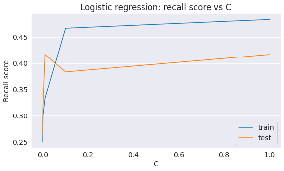

```python
C=[1,0.1,0.01,0.001,0.0001]

# Create lists to save the values of recall score on training and test sets
train_recall = []
test_recall = []

for c in C:
  log_reg_poly = LogisticRegression(C = c, random_state=42, solver='lbfgs', max_iter=5000).fit(X_train, Y_train)
  train_recall.append(cross_val_score(log_reg_poly, X_test, Y_test, cv=skf,scoring='recall').mean())
  test_recall.append(recall_score(Y_test, log_reg_poly.predict(X_test)))

#print("Best recall score on test dataset is {:.2f}% with C={} ".format(max(test_recall)*100, C[np.argmax(test_recall)]))

# plot graph of recall score vs. C
plt.plot(C, train_recall, label='train')
plt.plot(C, test_recall, label='test')
plt.legend()
plt.xlabel('C')
plt.ylabel('Recall score')
plt.title('Logistic regression: recall score vs C');
```

```python
test_recall
```

```
[0.4166666666666667,
 0.38333333333333336,
 0.4166666666666667,
 0.31666666666666665,
 0.26666666666666666]
```

We get the maximum recall scoee on test set with overfitting at C=0.01

```python
# Final logistc model
log_reg_poly = LogisticRegression(C = 0.01, random_state=42, solver='lbfgs', max_iter=5000).fit(X_train, Y_train)
print('Recall score on test dataset: {:.2f}'.format(recall_score(Y_test, log_reg_poly.predict(X_test))))
print('\nAUC ROC score on test dataset: {:.2f}'.format(roc_auc_score(Y_test,log_reg_poly.predict_proba(X_test)[:, 1])))
```

```
Recall score on test dataset: 0.42

AUC ROC score on test dataset: 0.78
```

### 7.3 Random Forest

- find optimal number of trees
- max depth
- min number of samples per leaf
- max features

Now, let's try to improve this result. Let's start with number of trees.

```
Best recall score on test dataset is 68.29% with 20 trees
```

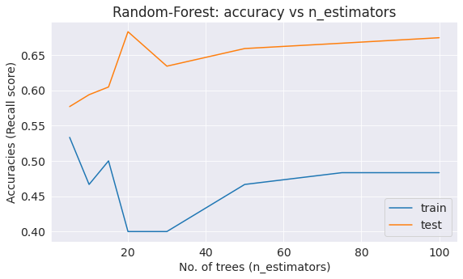

```python
# Create lists to save the values of accuracy on training and test sets
train_acc = []
test_acc = []
trees_grid = [5, 10, 15, 20, 30, 50, 75, 100]

for ntrees in trees_grid:
    rf = RandomForestClassifier(n_estimators=ntrees, random_state=42, n_jobs=-1).fit(X_train, Y_train)
    train_acc.append(cross_val_score(rf, X_test, Y_test, cv=skf, scoring='recall').mean())
    test_acc.append(recall_score(rf.predict(X_test), Y_test))
print("Best recall score on test dataset is {:.2f}% with {} trees".format(max(test_acc)*100,
                                                         trees_grid[np.argmax(test_acc)]))
# plot
plt.plot(trees_grid, train_acc, label='train')
plt.plot(trees_grid, test_acc, label='test')
plt.legend()
plt.xlabel('No. of trees (n_estimators)')
plt.ylabel('Accuracies (Recall score)')
plt.title('Random-Forest: accuracy vs n_estimators');
```

Best accuracy is achived with 20 tress.

```python
# Initialize the set of parameters for exhaustive search and fit
parameters = {'max_features': [7, 10, 16, 18],
              'min_samples_leaf': [1, 3, 5, 7],
              'max_depth': [15, 20, 24, 27]}
rf = RandomForestClassifier(n_estimators=20, random_state=42, n_jobs=-1)
gcv = GridSearchCV(rf, parameters, n_jobs=-1, cv=skf, verbose=1, scoring='recall')
gcv_fit= gcv.fit(X_train, Y_train)
```

```
Fitting 10 folds for each of 64 candidates, totalling 640 fits
```

```
[Parallel(n_jobs=-1)]: Using backend LokyBackend with 2 concurrent workers.
[Parallel(n_jobs=-1)]: Done  46 tasks      | elapsed:    5.5s
[Parallel(n_jobs=-1)]: Done 196 tasks      | elapsed:   22.1s
[Parallel(n_jobs=-1)]: Done 446 tasks      | elapsed:   49.8s
[Parallel(n_jobs=-1)]: Done 640 out of 640 | elapsed:  1.2min finished
```

```python
# evaluate on train and test datasets
cross_val= cross_val_score(gcv_fit.best_estimator_, X_train, Y_train, cv=skf,scoring='recall').mean()
recall_sc=recall_score(Y_test,gcv_fit.best_estimator_.predict(X_test))
roc_sc= roc_auc_score(Y_test,gcv_fit.best_estimator_.predict_proba(X_test)[:, 1])
# print scores
print("GCV best parameters: ",gcv.best_params_)
print("GCV best score: {:.2f}".format(gcv.best_score_))
print("Cross val score on train dataset: {:.2f}".format(cross_val))
print("Recall score on test dataset: {:.2f}".format(recall_sc))
print("ROC AUC score on test dataset: {:.2f}".format(roc_sc))
```

```
GCV best parameters:  {'max_depth': 20, 'max_features': 18, 'min_samples_leaf': 3}
GCV best score: 0.48
Cross val score on train dataset: 0.48
Recall score on test dataset: 0.40
ROC AUC score on test dataset: 0.74
```

### 7.4 GaussianNB

```python
# model
gnb= GaussianNB()
gnb.fit(X_train, Y_train)
#evaluate
print('Train accuracy: {:.2f}'.format(cross_val_score(gnb, X_train, Y_train, cv=skf, scoring='recall').mean()))
print('Recall score test dataset: {:.2f}'.format(recall_score(Y_test, gnb.predict(X_test))))
print('ROC AUC score test dataset: {:.2f}'.format(roc_auc_score(Y_test, gnb.predict_proba(X_test)[:,1])))
```

```
Train accuracy: 0.67
Recall score test dataset: 0.67
ROC AUC score test dataset: 0.78
```

### 7.5 XGBoost

```
Best recall score on test dataset is 66.67% with 10 estimators
```

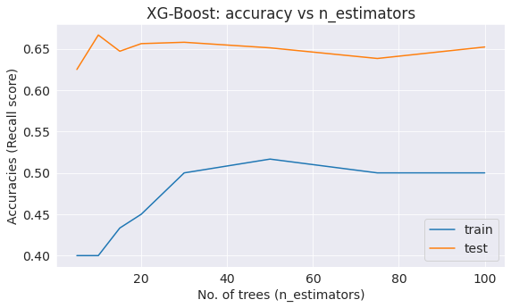

```python
# Create lists to save the values of accuracy on training and test sets
train_acc = []
test_acc = []
estimator_grid = [5, 10, 15, 20, 30, 50, 75, 100]

for nestimator in estimator_grid:
    xg = XGBClassifier(n_estimators=nestimator, random_state=42, n_jobs=-1).fit(X_train, Y_train)
    train_acc.append(cross_val_score(xg, X_test, Y_test, cv=skf, scoring='recall').mean())
    test_acc.append(recall_score(xg.predict(X_test), Y_test))
print("Best recall score on test dataset is {:.2f}% with {} estimators".format(max(test_acc)*100,
                                                         estimator_grid[np.argmax(test_acc)]))
# plot
plt.plot(estimator_grid, train_acc, label='train')
plt.plot(estimator_grid, test_acc, label='test')
plt.legend()
plt.xlabel('No. of trees (n_estimators)')
plt.ylabel('Accuracies (Recall score)')
plt.title('XG-Boost: accuracy vs n_estimators');
```

```python
#model
model_xg = XGBClassifier(random_state=42)
model_xg.fit(X_train, Y_train)
#evaluate
print('Train accuracy:', cross_val_score(model_xg, X_train, Y_train, cv=skf, scoring='recall').mean())
print('Recall score on test dataset:', recall_score(Y_test, model_xg.predict(X_test)))
print('ROC AUC score on test dataset:', roc_auc_score(Y_test, model_xg.predict_proba(X_test)[:,1]))
```

```
Train accuracy: 0.45
Recall score on test dataset: 0.5
ROC AUC score on test dataset: 0.7957142857142858
```

```python
# Initialize the set of parameters for exhaustive search and fit
parameters = {'max_features': [7, 10, 16, 18],
              'min_samples_leaf': [1, 3, 5, 7],
              'max_depth': [15, 20, 24, 27]}
model_xg = XGBClassifier(n_estimators=10, random_state=42, n_jobs=-1)
gcv = GridSearchCV(model_xg, parameters, n_jobs=-1, cv=skf, verbose=1, scoring='recall')
gcv_fit= gcv.fit(X_train, Y_train)
```

```
Fitting 10 folds for each of 64 candidates, totalling 640 fits
```

```
[Parallel(n_jobs=-1)]: Using backend LokyBackend with 2 concurrent workers.
[Parallel(n_jobs=-1)]: Done  88 tasks      | elapsed:    4.6s
[Parallel(n_jobs=-1)]: Done 388 tasks      | elapsed:   20.1s
[Parallel(n_jobs=-1)]: Done 640 out of 640 | elapsed:   33.0s finished
```

```python
gcv.best_params_, gcv.best_score_
```

```
({'max_depth': 15, 'max_features': 7, 'min_samples_leaf': 1}, 0.4625)
```

```python
# evaluate on train and test datasets
cross_val= cross_val_score(gcv_fit.best_estimator_, X_train, Y_train, cv=skf,scoring='recall').mean()
recall_sc=recall_score(Y_test,gcv_fit.best_estimator_.predict(X_test))
roc_sc= roc_auc_score(Y_test,gcv_fit.best_estimator_.predict_proba(X_test)[:, 1])
# print scores
print("GCV best parameters: ",gcv.best_params_)
print("GCV best score: {:.2f}".format(gcv.best_score_))
print("Cross val score on train dataset: {:.2f}".format(cross_val))
print("Recall score on test dataset: {:.2f}".format(recall_sc))
print("ROC AUC score on test dataset: {:.2f}".format(roc_sc))
```

```
GCV best parameters:  {'max_depth': 15, 'max_features': 7, 'min_samples_leaf': 1}
GCV best score: 0.46
Cross val score on train dataset: 0.46
Recall score on test dataset: 0.43
ROC AUC score on test dataset: 0.73
```

### 7.6 KNN

```python
from sklearn.neighbors import KNeighborsClassifier
knn= KNeighborsClassifier(n_neighbors = 1)
knn.fit(X_train, Y_train)
#evaluate
print('Train accuracy:{:.2f}'.format(cross_val_score(knn, X_train, Y_train, cv=skf, scoring='recall').mean()))
print('Recall score on test dataset:{:.2f}'.format(recall_score(Y_test, knn.predict(X_test))))
print("ROC AUC score on test dataset: {:.2f}".format(roc_auc_score(Y_test,gcv_fit.best_estimator_.predict_proba(X_test)[:, 1])))
```

```
Train accuracy:0.49
Recall score on test dataset:0.35
ROC AUC score on test dataset: 0.73
```

## Summary

[output not shown]

```python
import jovian
```

```python
jovian.commit()
```

## References and Future Work

Machine learning can be used on this dataset to develop a model that can predict bad loans. This might require the use of classifiers.

**References:**

1. Jovian Zero to Pandas course (https://jovian.ai/learn/data-analysis-with-python-zero-to-pandas)
2. https://seaborn.pydata.org
3. https://pandas.pydata.org
4. MLCourse.ai (https://mlcourse.ai/lectures)
5. Accuracy, precision, recall, or F1 by Koo Ping Shung (https://towardsdatascience.com/accuracy-precision-recall-or-f1-331fb37c5cb9)

**Future work:**

Try models:

1. Neural network model
2. Support Vector Classification

```python
import jovian
```

```python
jovian.commit()
```

```
[jovian] Detected Colab notebook...
[jovian] Uploading colab notebook to Jovian...
[jovian] Capturing environment..
[jovian] Committed successfully! https://jovian.ai/aswiniabraham/german-credit-risk-blog
```

```
'https://jovian.ai/aswiniabraham/german-credit-risk-blog'
```